# Part 2 - Introduction to the Tidyverse

October 15, 2020

## What we learned in the previous class

- Getting up and running in RStudio
- Core R concepts
  - Data types
  - Relationship between data and functions
- How to import data
- Regularly used data summary functions
- Assignment operator
- Troubleshooting basics

## What we’ll learn today

- A bit more about troubleshooting
- Chaining together functions with a pipe operator (`%>%`)
- Selecting variables
- Creating variables
- Updating values
- Subsetting tibbles/data frames
- Aggregation

## Troubleshooting your R code

Make sure…

- You loaded your libraries
- Arguments in your functions are comma-separated
- Your functions have start and closing parentheses
- You have start and end quotation marks where relevant
- The variable type is correct to perform the function you call
  - For example you probably don’t want to run `min()` on a character string
- Your definition operator looks like this

```r
<-
```

## Troubleshooting your R code

So, how then do you “make sure” your code is error-free?

- Run code line by line
- Ensure the code finished running (`+`s vs. `>`s in the R console)
- Red “x” annotation beside line numbers (after saving your file)

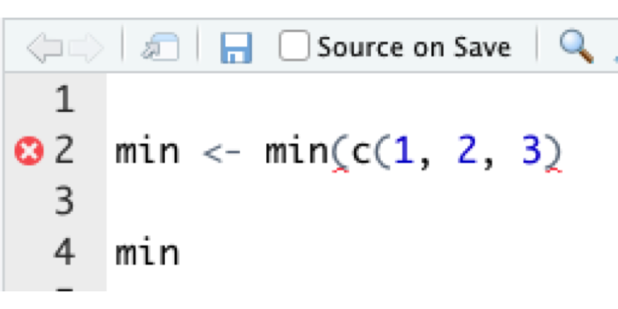

## Let’s warm up with a practice troubleshooting exercise

**Exercise 1 - 5 minutes**

- Correct 7 coding mistakes
- Reference the previous slide for help

[figure not shown]

## Select, create, and rename variables

## Select, create, and rename variables

- `select()` keeps the named variables from the dataset
- You can also remove variables from the dataset with `-`
- Let’s keep it simple for now and not nest functions within `select()`
  - Exception: `everything()`
- Use `` '``' `` for multi-word variables and variable names that begin with numbers

```r
head(select(airbnb, host_id, reviews, rating, price), 3)
## # A tibble: 3 × 4
##   host_id reviews rating price
##     <dbl>   <dbl>  <dbl> <dbl>
## 1    2536      21    5     250
## 2    4193       1   NA     100
## 3   35749      63    4.5    82
```

## Select, create, and rename variables

- `select()` keeps the named variables from the dataset
- You can also remove variables from the dataset with `-`
- Let’s keep it simple for now and not nest functions within `select()`
  - Exception: `everything()`
- Use `` '``' `` for multi-word variables and variable names that begin with numbers

```r
head(select(select(airbnb, host_id, reviews, rating, price), -rating), 3)
## # A tibble: 3 × 3
##   host_id reviews price
##     <dbl>   <dbl> <dbl>
## 1    2536      21   250
## 2    4193       1   100
## 3   35749      63    82
```

## Select, create, and rename variables

- `select()` keeps the named variables from the dataset
- You can also remove variables from the dataset with `-`
- Let’s keep it simple for now and not nest functions within `select()`
  - Exception: `everything()`
- Use `` '``' `` for multi-word variables and variable names that begin with numbers

```r
head(select(select(airbnb, host_id, reviews, rating, price), host_id, price, everything()), 3)
## # A tibble: 3 × 4
##   host_id price reviews rating
##     <dbl> <dbl>   <dbl>  <dbl>
## 1    2536   250      21    5
## 2    4193   100       1   NA
## 3   35749    82      63    4.5
```

## Make your code as readable as possible

- A whole course could be taught on code format
- **BOTTOM LINE (FOR OUR COURSE)**
  - Use the `tidyverse` pipe operator (`%>%`) when working with tibbles/data frames

**Bad**

```r
head(select(select(airbnb, host_id, reviews, rating, price), host_id, price, everything()), 3)
```

**Good**

```r
airbnb %>%
  select(host_id, reviews, rating, price) %>%
  select(host_id, price, everything()) %>%
  head(3)
```

## Make your code as readable as possible

- Use the `tidyverse` pipe operator (`%>%`) when working with tibbles/data frames
  - Easier to read and troubleshoot
  - Easier to comment (write end of line comments or above line comments)
  - Modular

```r
airbnb %>%
  select(host_id, reviews, rating, price) %>%
  select(host_id, price, everything()) %>%
  head(3)
```

## Make your code as readable as possible

- No firm, binding rule for using (or not using) the pipe operator with vectors
  - Ask yourself: “which format is easiest to read?”
  - Depends on the number of functions
  - Depends on whether you are pulling a variable of tibble that you are processing
    - `pull()`

```r
length(unique(airbnb$address))
airbnb$address %>% unique() %>% length()
airbnb %>% pull(address) %>% unique() %>% length()
```

## Select, create, and rename variables

- `mutate()` creates variables
- Create multiple variables in one go
- Use functions you already learned within `mutate()`
  - `min()`, `max()`, `mean()`
  - `as.character()`, `as.factor()`, `as.numeric()`
- Use `ifelse()` within `mutate()`

```r
airbnb %>%
  mutate(
    cost_per_room = accommodates / price
    , mean_price = mean(price)
    )
```

## Select, create, and rename variables

- `mutate()` creates variables
- Create multiple variables in one go
- Use functions you already learned within `mutate()`
  - `min()`, `max()`, `mean()`
  - `as.character()`, `as.factor()`, `as.numeric()`
- Use `ifelse()` within `mutate()`

```r
x <- c(1, 2, 3)
y <- c(4, 5, 1)

ifelse(x > y, 'yes', 'no')
```

## Select, create, and rename variables

- `mutate()` creates variables
- Create multiple variables in one go
- Use functions you already learned within `mutate()`
  - `min()`, `max()`, `mean()`
  - `as.character()`, `as.factor()`, `as.numeric()`
- Use `ifelse()` within `mutate()`

```r
x <- c(1, 2, 3)
y <- c(4, 5, 1)

ifelse(x > y, 'yes', 'no')
## [1] "no"  "no"  "yes"
```

## Select, create, and rename variables

- A little more on `ifelse()`
  - A logical test with a true-or-false outcome
  - To make comparisons use: `==`, `<`, `<=`, `>`, `>=`, `!=`, `%in%`, `!`
  - Also can use: `is.numeric()`, `is.character()`, etc.

```r
city_1 <- 'San Francisco'
city_2 <- 'Portland'
california <- c('San Francisco', 'Los Angeles', 'San Diego')

ifelse(city_1 %in% california, 'yes', 'no')
## [1] "yes"
ifelse(city_2 %in% california, 'yes', 'no')
## [1] "no"
ifelse(237 %in% 200:300, 'yes', 'no')
## [1] "yes"
```

## Select, create, and rename variables

- A little more on `ifelse()`
  - A logical test with a true-or-false outcome
  - To make comparisons use: `==`, `<`, `<=`, `>`, `>=`, `!=`, `%in%`, `!`
  - Also can use: `is.numeric()`, `is.character()`, etc.

```r
city_1 <- 'San Francisco'
city_2 <- 'Portland'
california <- c('San Francisco', 'Los Angeles', 'San Diego')

ifelse(! city_1 %in% california, 'yes', 'no')
## [1] "no"
ifelse(! city_2 %in% california, 'yes', 'no')
## [1] "yes"
ifelse(! 237 %in% 200:300, 'yes', 'no')
## [1] "no"
```

## Select, create, and rename variables

- `mutate()` creates variables
- Create multiple variables in one go
- Use functions you already learned within `mutate()`
  - `min()`, `max()`, `mean()`
  - `as.character()`, `as.factor()`, `as.numeric()`
- Use `ifelse()` within `mutate()`

```r
airbnb %>%
  mutate(
    cost_per_room = accommodates / price
    , mean_price = mean(price)
    , seattle_address = ifelse(address == 'Seattle', 'y', NA)
    , large = ifelse(accommodates > 5, 'y', NA)
    )
```

## Select, create, and rename variables

```r
airbnb %>%
  mutate(
    cost_per_room = accommodates / price
    , mean_price = mean(price)
    , seattle_address = ifelse(address == 'Seattle', 'y', NA)
    , large = ifelse(accommodates > 5, 'y', NA)
    ) %>%
  select(room_id, host_id, cost_per_room, mean_price, seattle_address, large) %>%
  head(5)
## # A tibble: 5 × 6
##   room_id host_id cost_per_room mean_price seattle_address large
##     <dbl>   <dbl>         <dbl>      <dbl> <chr>           <chr>
## 1    2318    2536        0.032        112. y               y
## 2    3335    4193        0.04         112. y               <NA>
## 3    4291   35749        0.0244       112. y               <NA>
## 4    5682    8993        0.0408       112. y               <NA>
## 5    6606   14942        0.0222       112. y               <NA>
```

## Select, create, and rename variables

**Exercise - 5 minutes**  
- With the `climate` dataset, create variables called `high_uncertainty` and `winter` - In `high_uncertainty`, flag with a `1` all observations where `uncertainty` is greater than 1.5. All other records should have a `0`  
- In `winter`, flag with a `1` all observations where month is a 1, 2, 12.  
- Only report the following variables in the output: `country`, `city`, `high_uncertainty` and `winter`

```r
climate %>%
  mutate(
    high_uncertainty = ifelse(uncertainty > 1.5, 1, 0)
    , winter = ifelse(month %in% c(1, 2, 12), 1, 0)
    ) %>%
  select(country, city, high_uncertainty, winter) %>%
  head()
```

## Select, create, and rename variables

**Exercise - 5 minutes**  
- With the `climate` dataset, create variables called `high_uncertainty` and `winter` - In `high_uncertainty`, flag with a `1` all observations where `uncertainty` is greater than 1.5. All other records should have a `0`  
- In `winter`, flag with a `1` all observations where month is a 1, 2, 12.  
- Only report the following variables in the output: `country`, `city`, `high_uncertainty` and `winter`

```r
climate %>%
  mutate(
    high_uncertainty = ifelse(uncertainty > 1.5, 1, 0)
    , winter = ifelse(month %in% c(1, 2, 12), 1, 0)
    ) %>%
  select(country, city, high_uncertainty, winter) %>%
  head()
## # A tibble: 6 × 4
##   country     city    high_uncertainty winter
##   <chr>       <chr>              <dbl>  <dbl>
## 1 Ivory Coast Abidjan                0      1
## 2 Ivory Coast Abidjan                0      1
## 3 Ivory Coast Abidjan                1      0
## 4 Ivory Coast Abidjan                0      0
## 5 Ivory Coast Abidjan                0      0
## 6 Ivory Coast Abidjan                0      0
```

## Select, create, and rename variables

- `transmute()` = `mutate()` + `select()`

```r
climate %>%
  mutate(
    high_uncertainty = ifelse(uncertainty > 1.5, 1, 0)
    , winter = ifelse(month %in% c(1, 2, 12), 1, 0)
    ) %>%
  select(country, city, high_uncertainty, winter)
```

## Select, create, and rename variables

- `transmute()` = `mutate()` + `select()`

```r
climate %>%
  transmute(
    country
    , city
    , high_uncertainty = ifelse(uncertainty > 1.5, 1, 0)
    , winter = ifelse(month %in% c(1, 2, 12), 1, 0)
    )
```

| country | city | high_uncertainty | winter |
| --- | --- | --- | --- |
| Ivory Coast | Abidjan | 0 | 1 |
| Ivory Coast | Abidjan | 0 | 1 |
| Ivory Coast | Abidjan | 1 | 0 |
| Ivory Coast | Abidjan | 0 | 0 |
| Ivory Coast | Abidjan | 0 | 0 |
| Ivory Coast | Abidjan | 0 | 0 |

## Select, create, and rename variables

- `transmute()` = `mutate()` + `select()`
- Keep unmanipulated variables too if you would like

```r
climate %>%
  transmute(
    country
    , city
    , high_uncertainty = ifelse(uncertainty > 1.5, 1, 0)
    , winter = ifelse(month %in% c(1, 2, 12), 1, 0)
    )
## # A tibble: 239,177 × 4
##    country     city    high_uncertainty winter
##    <chr>       <chr>              <dbl>  <dbl>
##  1 Ivory Coast Abidjan                0      1
##  2 Ivory Coast Abidjan                0      1
##  3 Ivory Coast Abidjan                1      0
##  4 Ivory Coast Abidjan                0      0
##  5 Ivory Coast Abidjan                0      0
##  6 Ivory Coast Abidjan                0      0
##  7 Ivory Coast Abidjan                0      0
##  8 Ivory Coast Abidjan                0      0
##  9 Ivory Coast Abidjan                0      0
## 10 Ivory Coast Abidjan                0      0
## # … with 239,167 more rows
```